# Regresja i analiza wariancji - Sprawozdanie 3

Metody klasyfikacji - sprawozdanie

Marcin Ból

Politechnika Krakowska

# Termin oddania : Wtorek 31.05.2022 23:59

# Zadanie

W pliku ‘banknotes.csv’ znadjują się dane opisujące obrazy banknotów. Dane powstały poprzez transformatę falkową (wavelet transform) zastosowaną do obrazów w skali szarości rozmiaru 400x400 pikseli. Po zastosowaniu transformaty wyliczono cztery charakterystyki liczbowe obrazu - wariancję, skośność, kurtozę oraz entropię.

Za pomocą modelu regresji logistycznej sprawdź czy za pomocą tej metody jesteśmy w stanie dobrze odróżnić banknoty prawdziwe od fałszywych.

- Zbuduj i zinterpretuj model regresji logistycznej (w razie otrzymania ostrzeżenia od software’u stosownie należy je skomentować, ale się nim nie przejmować).
- Zbadaj i zinterpretuj jego charakterystyki liczbowe za pomocą macierzy pomyłek.
- Wyrysuj krzywą ROC otrzymanego modelu i podaj AUC. Zinterpretuj otrzymane wyniki.

```r
library(tidyverse)
library(caret)
library(ggfortify)
bank <- readr::read_csv('banknote.csv', col_names = FALSE)
head(bank)
```

| X1 | X2 | X3 | X4 | X5 |
| --- | --- | --- | --- | --- |
| 3.62160 | 8.6661 | -2.8073 | -0.44699 | 0 |
| 4.54590 | 8.1674 | -2.4586 | -1.46210 | 0 |
| 3.86600 | -2.6383 | 1.9242 | 0.10645 | 0 |
| 3.45660 | 9.5228 | -4.0112 | -3.59440 | 0 |
| 0.32924 | -4.4552 | 4.5718 | -0.98880 | 0 |
| 4.36840 | 9.6718 | -3.9606 | -3.16250 | 0 |

Sprawdźmy, czy mamy mniej więcej tyle samo elementów z klasy 0 co z klasy 1.

```r
table(bank$X5)
```

```
##
##   0   1
## 762 610
```

Odpowiedź jest pozytywna, więc przejdźmy do podziału naszego zbioru danych na zbiór treningowy i zbiór testowy.

```r
train_test_split <- createDataPartition(bank$X5, list = FALSE, p=0.75)
bank_train <- bank[train_test_split,]
bank_test <- bank[-train_test_split,]
```

Budujemy model regresji logistycznej.

```r
logistic <-glm(X5 ~. ,data=bank_train, family = "binomial")
summary(logistic)
```

```
##
## Call:
## glm(formula = X5 ~ ., family = "binomial", data = bank_train)
##
## Deviance Residuals:
##      Min        1Q    Median        3Q       Max
## -1.73795   0.00000   0.00000   0.00064   2.11308
##
## Coefficients:
##             Estimate Std. Error z value Pr(>|z|)
## (Intercept)   6.7685     1.5994   4.232 2.32e-05 ***
## X1           -7.2785     1.8445  -3.946 7.94e-05 ***
## X2           -3.9932     0.9741  -4.099 4.14e-05 ***
## X3           -4.9817     1.2429  -4.008 6.12e-05 ***
## X4           -0.6426     0.3693  -1.740   0.0818 .
## ---
## Signif. codes:  0 '***' 0.001 '**' 0.01 '*' 0.05 '.' 0.1 ' ' 1
##
## (Dispersion parameter for binomial family taken to be 1)
##
##     Null deviance: 1416.96  on 1028  degrees of freedom
## Residual deviance:   38.33  on 1024  degrees of freedom
## AIC: 48.33
##
## Number of Fisher Scoring iterations: 12
```

```r
pred <- predict(logistic, bank_test, type = 'response')
predc <- ifelse(pred > 0.5, 1, 0)
confusionMatrix(factor(predc), factor(bank_test$X5))
```

```
## Confusion Matrix and Statistics
##
##           Reference
## Prediction   0   1
##          0 195   1
##          1   3 144
##
##                Accuracy : 0.9883
##                  95% CI : (0.9704, 0.9968)
##     No Information Rate : 0.5773
##     P-Value [Acc > NIR] : <2e-16
##
##                   Kappa : 0.9761
##
##  Mcnemar's Test P-Value : 0.6171
##
##             Sensitivity : 0.9848
##             Specificity : 0.9931
##          Pos Pred Value : 0.9949
##          Neg Pred Value : 0.9796
##              Prevalence : 0.5773
##          Detection Rate : 0.5685
##    Detection Prevalence : 0.5714
##       Balanced Accuracy : 0.9890
##
##        'Positive' Class : 0
##
```

Model jest zaskakująco dobry - dokładność wynosi aż 98,83%. Sprawdźmy jak wygląda w tym przypadku krzywa ROC.

```r
roc <- pROC::roc(response = bank_test$X5, predictor = pred)
roc
```

```
##
## Call:
## roc.default(response = bank_test$X5, predictor = pred)
##
## Data: pred in 198 controls (bank_test$X5 0) < 145 cases (bank_test$X5 1).
## Area under the curve: 0.9998
```

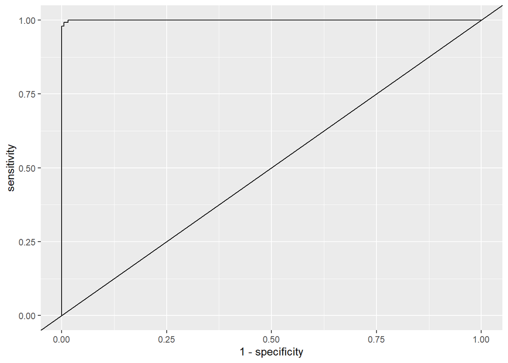

```r
pROC::ggroc(roc, legacy.axes = TRUE) + geom_abline(slope = 1, intercept = 0)
```

Krzywa ROC świadczy o tym, że nasz model jest prawie idealny.

```r
roc$auc
```

```
## Area under the curve: 0.9998
```

Potwierdza to również współczynnik AUC, który wynosi prawie 1.